# LIIA Data Analysis: Gaussian Mixture Modeling for the Abeta 42/40 Ratio

Yue Wang

2024-05-09

# Introduction

This report presents a detailed descriptive analysis of CSF and plasma biomarkers within the LIIA cohort. Additionally, it outlines the application of Gaussian mixture modeling to the CSF and plasma Abeta 42/40 ratios.

# Methods

- Descriptive statistics including the mean, standard deviation, minimum, and maximum values were calculated for all biomarkers, presented in Table 1.
- Histograms were generated to visually inspect the distribution of these biomarkers.
- Particularly, the CSF Abeta42/40 ratio showed a bimodal distribution, motivating the use of Gaussian mixture models (GMMs) for further analysis. A Gaussian mixture model is a probabilistic model that assumes all the data points are generated from a mixture of a finite number of Gaussian distributions with unknown parameters. In our case, a two-component GMM was fitted to the CSF Abeta42/40 ratio data to classify subjects as either ‘CSF Amyloid negative’ or ‘CSF Amyloid positive’. Despite the absence of a bimodal distribution in the plasma Abeta42/40 ratio data, a similar GMM analysis was applied to the plasma Abeta42/40 ratio for comparative analysis.
- The classification results from the CSF were then used to find an optimal cutoff using the Youden’s method, which maximizes the sum of sensitivity and specificity. This cutoff defines ‘CSF Amyloid negative’ below the threshold and ‘CSF Amyloid positive’ above it. The same methodology was used for the plasma data. Subsequently, a descriptive table was generated to compare the classification results derived from the CSF and plasma data.
- Since the CSF-based classification is more accurate, an alternative optimal cutoff point for the Plasma Abeta42/40 ratio was determined to align it with the CSF classification outcomes.

# Table 1

The table below presents a descriptive analysis of CSF and plasma biomarkers within the LIIA cohort, for both baseline and follow-up observations. Note that there is no plasma data available for the follow-up group.

```r
LIIA_dat <- read_excel('/Volumes/dept/SPH/SPH-CIDA/BRANCHES/AlzheimersDisease/LIIA/Processed_LIIA_biomarker/LIIA Plasma and CSF Study.xlsx')
LIIA_dat <- LIIA_dat %>%
  mutate(`Plasma P-Tau181 (pg/ml)` = as.numeric(`Plasma P-Tau181 (pg/ml)`)) %>%
  mutate(`Plasma AB40 (pg/ml)` = as.numeric(`Plasma AB40 (pg/ml)`))

## obtain baseline and followup data -----
LIIA_dat$visit <- factor(substr(LIIA_dat$`Sample ID`, 11, 11), labels = c("baseline", "followup") )

LIIA_dat <- LIIA_dat %>%
  rename(CSF_P_Tau181 = `CSF P-Tau181 (pg/ml)`) %>%
  rename(CSF_Total_Tau = `CSF Total Tau (pg/ml)`) %>%
  rename(CSF_AB42 = `CSF AB42 (pg/ml)`) %>%
  rename(CSF_AB40 = `CSF AB40 (pg/ml)`) %>%
  rename(CSF_ABratio = `CSF AB42/40 Ratio`) %>%
  rename(Plasma_P_Tau181 = `Plasma P-Tau181 (pg/ml)`) %>%
  rename(Plasma_AB42 = `Plasma AB42 (pg/ml)`) %>%
  rename(Plasma_AB40 = `Plasma AB40 (pg/ml)`) %>%
  rename(Plasma_ABratio = `Plasma AB42/40 Ratio`)
#LIIA_baseline <- filter(LIIA_dat, visit==1)
#LIIA_followup <- filter(LIIA_dat, visit==2)

label(LIIA_dat$Plasma_ABratio) = "Plasma AB42/40 Ratio"
label(LIIA_dat$CSF_P_Tau181) = "CSF P-Tau181 (pg/ml)"
label(LIIA_dat$CSF_Total_Tau) = "CSF Total Tau (pg/ml)"
label(LIIA_dat$CSF_AB42) = "CSF AB42 (pg/ml)"
label(LIIA_dat$CSF_AB40) = "CSF AB40 (pg/ml)"
label(LIIA_dat$CSF_ABratio) = "CSF AB42/40 Ratio"
label(LIIA_dat$Plasma_P_Tau181)="Plasma P-Tau181 (pg/ml)"
label(LIIA_dat$Plasma_AB42)="Plasma AB42 (pg/ml)"
label(LIIA_dat$Plasma_AB40)="Plasma AB40 (pg/ml)"



table1(~CSF_P_Tau181+CSF_Total_Tau+CSF_AB42+CSF_AB40+CSF_ABratio+Plasma_P_Tau181+
         Plasma_AB42+Plasma_AB40+Plasma_ABratio|visit, data=LIIA_dat, caption = "Table 1: Basic descriptive statistics")
```

Table 1: Basic descriptive statistics

|  | baseline (N=131) | followup (N=15) | Overall (N=146) |
| --- | --- | --- | --- |
| CSF P-Tau181 (pg/ml) |  |  |  |
| Mean (SD) | 26.1 (12.9) | 29.9 (12.0) | 26.5 (12.9) |
| Median [Min, Max] | 22.5 [8.00, 77.4] | 29.8 [11.1, 59.9] | 23.5 [8.00, 77.4] |
| CSF Total Tau (pg/ml) |  |  |  |
| Mean (SD) | 207 (89.1) | 225 (86.7) | 209 (88.7) |
| Median [Min, Max] | 185 [75.0, 493] | 215 [94.0, 468] | 187 [75.0, 493] |
| CSF AB42 (pg/ml) |  |  |  |
| Mean (SD) | 740 (287) | 844 (245) | 751 (284) |
| Median [Min, Max] | 706 [225, 1920] | 826 [394, 1190] | 733 [225, 1920] |
| CSF AB40 (pg/ml) |  |  |  |
| Mean (SD) | 8590 (2670) | 9070 (2340) | 8640 (2640) |
| Median [Min, Max] | 8230 [3050, 17300] | 8820 [4130, 12400] | 8250 [3050, 17300] |
| CSF AB42/40 Ratio |  |  |  |
| Mean (SD) | 0.0866 (0.0204) | 0.0939 (0.0182) | 0.0873 (0.0202) |
| Median [Min, Max] | 0.0941 [0.0300, 0.119] | 0.100 [0.0586, 0.113] | 0.0946 [0.0300, 0.119] |
| Plasma P-Tau181 (pg/ml) |  |  |  |
| Mean (SD) | 0.990 (0.336) | NA (NA) | 0.990 (0.336) |
| Median [Min, Max] | 0.930 [0.440, 2.57] | NA [NA, NA] | 0.930 [0.440, 2.57] |
| Missing | 1 (0.8%) | 15 (100%) | 16 (11.0%) |
| Plasma AB42 (pg/ml) |  |  |  |
| Mean (SD) | 27.9 (4.64) | NA (NA) | 27.9 (4.64) |
| Median [Min, Max] | 28.0 [13.7, 42.5] | NA [NA, NA] | 28.0 [13.7, 42.5] |
| Missing | 0 (0%) | 15 (100%) | 15 (10.3%) |
| Plasma AB40 (pg/ml) |  |  |  |
| Mean (SD) | 292 (36.1) | NA (NA) | 292 (36.1) |
| Median [Min, Max] | 291 [209, 417] | NA [NA, NA] | 291 [209, 417] |
| Missing | 1 (0.8%) | 15 (100%) | 16 (11.0%) |
| Plasma AB42/40 Ratio |  |  |  |
| Mean (SD) | 0.0960 (0.0118) | NA (NA) | 0.0960 (0.0118) |
| Median [Min, Max] | 0.0957 [0.0689, 0.127] | NA [NA, NA] | 0.0957 [0.0689, 0.127] |
| Missing | 1 (0.8%) | 15 (100%) | 16 (11.0%) |

# Descriptive Figures

The figures below illustrate the distribution of CSF and plasma biomarkers across different visit groups. The distribution of the CSF Abeta 42/40 ratio shows a bimodal pattern, whereas such bimodality is less apparent in the plasma Abeta 42/40 ratio.

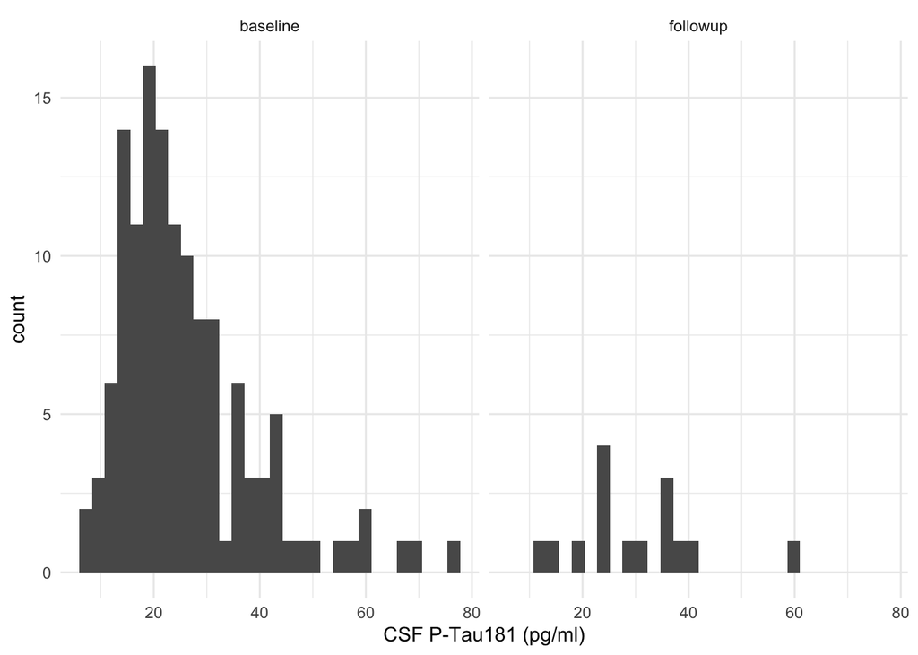

```r
ggplot(data=LIIA_dat, aes(x = CSF_P_Tau181)) +
  geom_histogram(position = "dodge", bins = 30) +
  facet_wrap(.~visit)+
  #scale_fill_manual(values = cb_palette) +
  #facet_grid(. ~ trp_status, scales = "free_y", space = "free_x") +
  theme_minimal()+
  labs(x = "CSF P-Tau181 (pg/ml)")
```

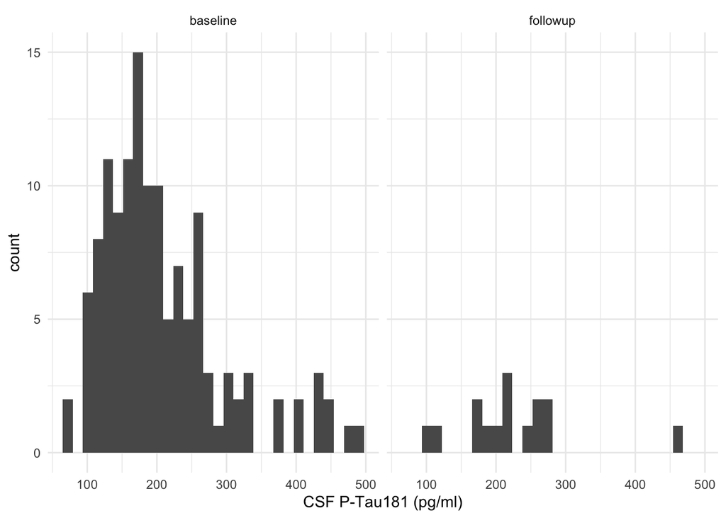

```r
  #geom_vline(xintercept = 0.05, col="red")

ggplot(data=LIIA_dat, aes(x = CSF_Total_Tau)) +
  geom_histogram(position = "dodge", bins = 30) +
  facet_wrap(.~visit)+
  #scale_fill_manual(values = cb_palette) +
  #facet_grid(. ~ trp_status, scales = "free_y", space = "free_x") +
  theme_minimal()+
  labs(x = "CSF P-Tau181 (pg/ml)")
```

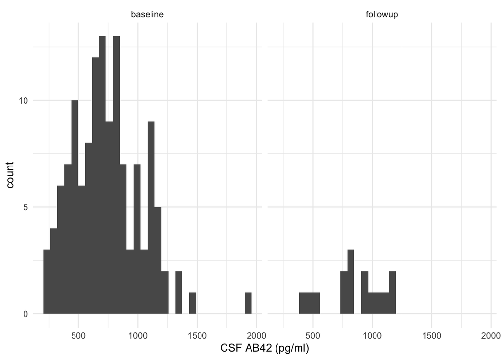

```r
#labs(title = "Unadjusted p value: interaction effect: full model", x = "p value", y = "Count") +
#geom_vline(xintercept = 0.05, col="red")

ggplot(data=LIIA_dat, aes(x = CSF_AB42)) +
  geom_histogram(position = "dodge", bins = 30) +
  facet_wrap(.~visit)+
  #scale_fill_manual(values = cb_palette) +
  #facet_grid(. ~ trp_status, scales = "free_y", space = "free_x") +
  theme_minimal()+
  labs(x = "CSF AB42 (pg/ml)")
```

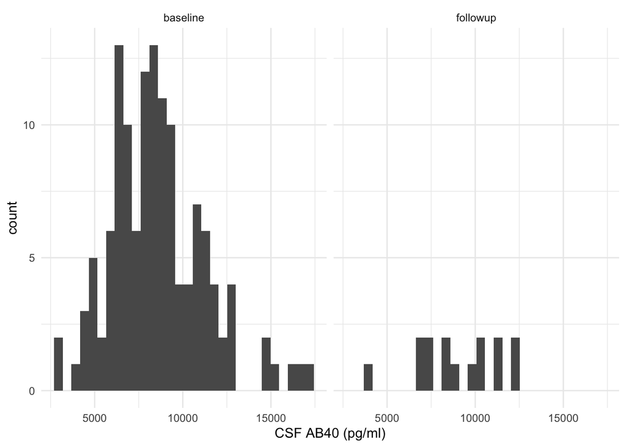

```r
#labs(title = "Unadjusted p value: interaction effect: full model", x = "p value", y = "Count") +
#geom_vline(xintercept = 0.05, col="red")

ggplot(data=LIIA_dat, aes(x = CSF_AB40)) +
  geom_histogram(position = "dodge", bins = 30) +
  facet_wrap(.~visit)+
  #scale_fill_manual(values = cb_palette) +
  #facet_grid(. ~ trp_status, scales = "free_y", space = "free_x") +
  theme_minimal()+
  labs(x = "CSF AB40 (pg/ml)")
```

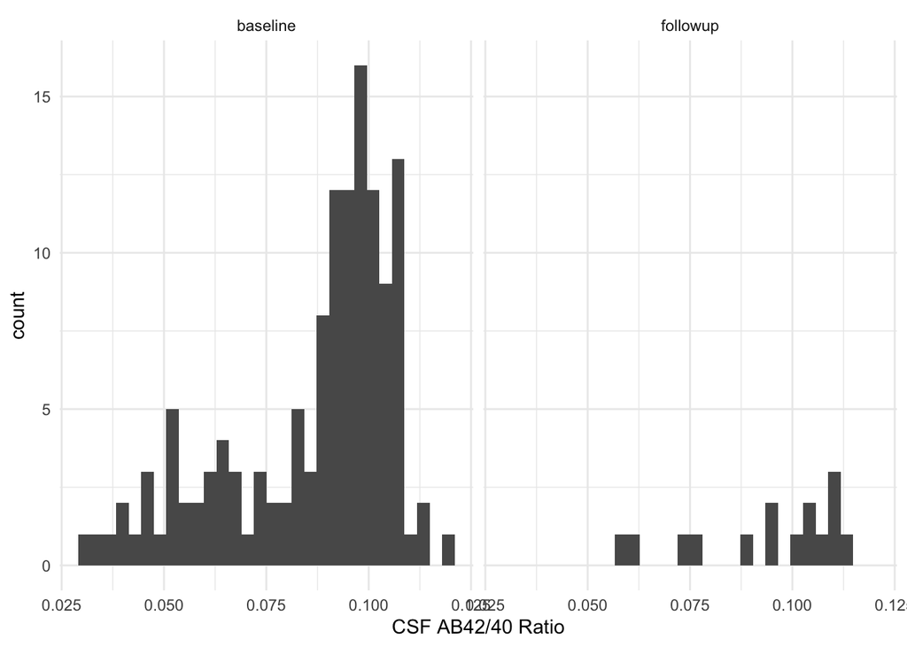

```r
#labs(title = "Unadjusted p value: interaction effect: full model", x = "p value", y = "Count") +
#geom_vline(xintercept = 0.05, col="red")

ggplot(data=LIIA_dat, aes(x = CSF_ABratio)) +
  geom_histogram(position = "dodge", bins = 30) +
  facet_wrap(.~visit)+
  #scale_fill_manual(values = cb_palette) +
  #facet_grid(. ~ trp_status, scales = "free_y", space = "free_x") +
  theme_minimal()+
  labs(x = "CSF AB42/40 Ratio")
```

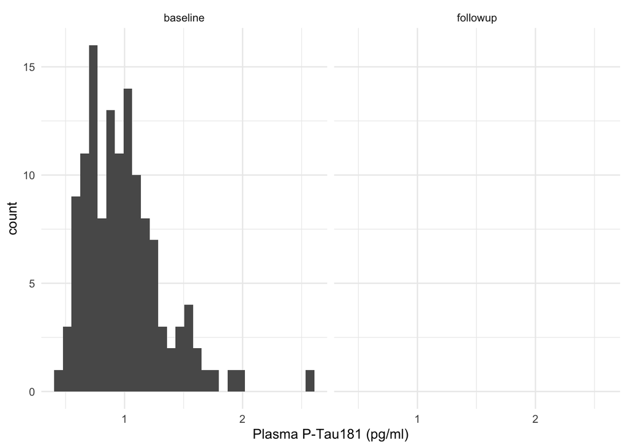

```r
#labs(title = "Unadjusted p value: interaction effect: full model", x = "p value", y = "Count") +
#geom_vline(xintercept = 0.05, col="red")

ggplot(data=LIIA_dat, aes(x = Plasma_P_Tau181)) +
  geom_histogram(position = "dodge", bins = 30) +
  facet_wrap(.~visit)+
  #scale_fill_manual(values = cb_palette) +
  #facet_grid(. ~ trp_status, scales = "free_y", space = "free_x") +
  theme_minimal()+
  labs(x="Plasma P-Tau181 (pg/ml)")
```

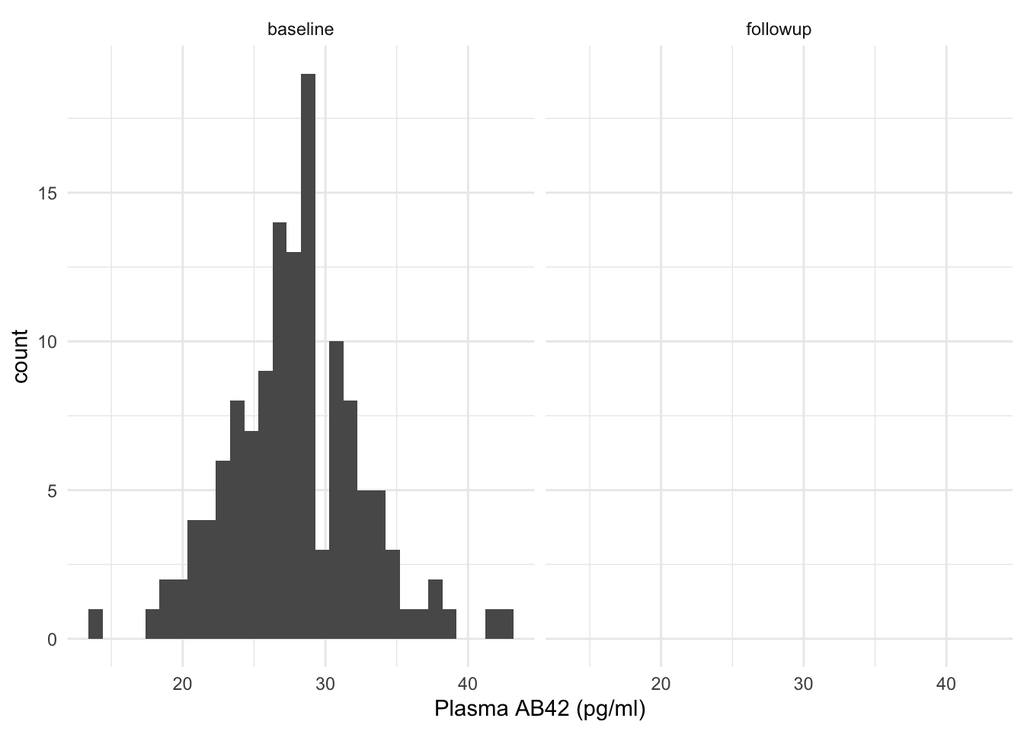

```r
#labs(title = "Unadjusted p value: interaction effect: full model", x = "p value", y = "Count") +
#geom_vline(xintercept = 0.05, col="red")


ggplot(data=LIIA_dat, aes(x = Plasma_AB42)) +
  geom_histogram(position = "dodge", bins = 30) +
  facet_wrap(.~visit)+
  #scale_fill_manual(values = cb_palette) +
  #facet_grid(. ~ trp_status, scales = "free_y", space = "free_x") +
  theme_minimal() +
  labs(x="Plasma AB42 (pg/ml)")
```

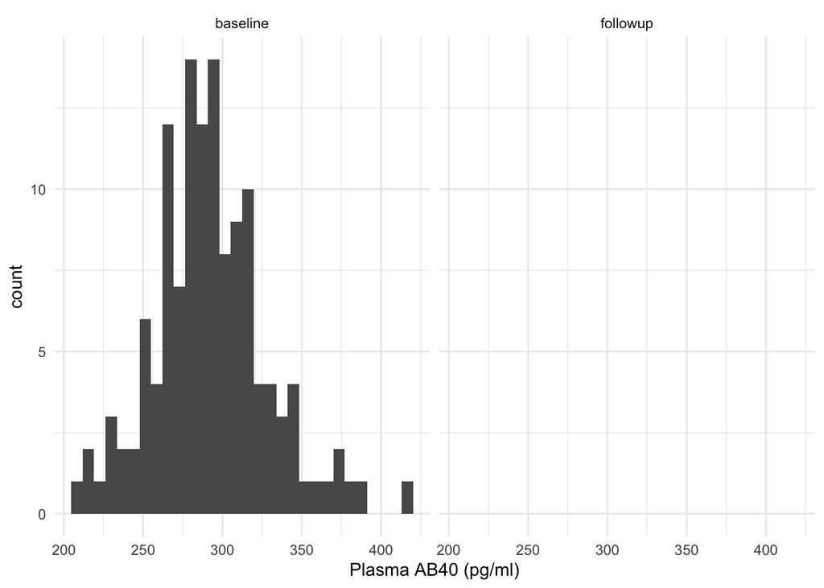

```r
#labs(title = "Unadjusted p value: interaction effect: full model", x = "p value", y = "Count") +
#geom_vline(xintercept = 0.05, col="red")


ggplot(data=LIIA_dat, aes(x = Plasma_AB40)) +
  geom_histogram(position = "dodge", bins = 30) +
  facet_wrap(.~visit)+
  #scale_fill_manual(values = cb_palette) +
  #facet_grid(. ~ trp_status, scales = "free_y", space = "free_x") +
  theme_minimal() +
  labs(x="Plasma AB40 (pg/ml)")
```

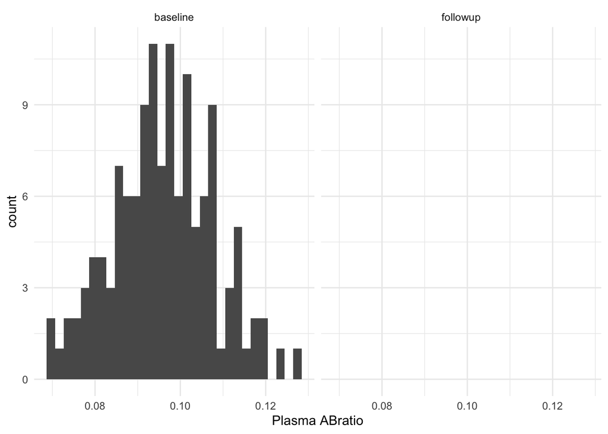

```r
#labs(title = "Unadjusted p value: interaction effect: full model", x = "p value", y = "Count") +
#geom_vline(xintercept = 0.05, col="red")


ggplot(data=LIIA_dat, aes(x = Plasma_ABratio)) +
  geom_histogram(position = "dodge", bins = 30) +
  facet_wrap(.~visit)+
  #scale_fill_manual(values = cb_palette) +
  #facet_grid(. ~ trp_status, scales = "free_y", space = "free_x") +
  theme_minimal() +
  labs(x="Plasma ABratio")
```

```r
#labs(title = "Unadjusted p value: interaction effect: full model", x = "p value", y = "Count") +
#geom_vline(xintercept = 0.05, col="red")
#---------------------------------------------------------
```

# GMM results

Since the followup group has limited data, the GMM was only fitted to the baseline group.

## CSF AB42/40 Ratio

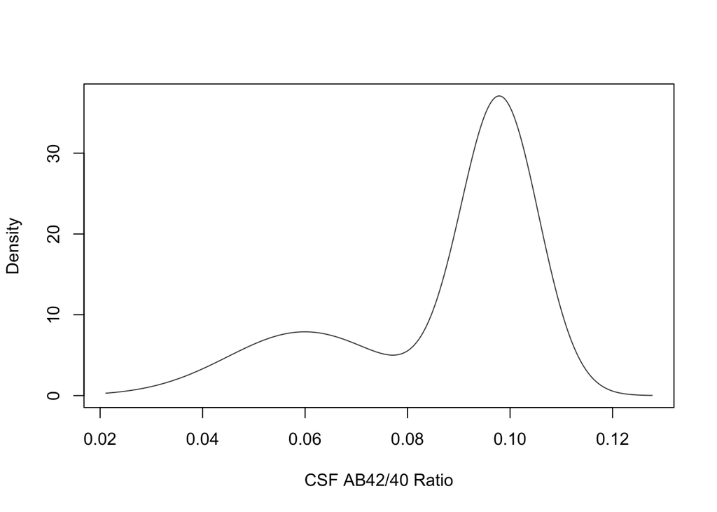

```r
#### CSF ----
LIIA_baseline <- filter(LIIA_dat, visit=="baseline")

fit = Mclust(LIIA_baseline$CSF_ABratio, G=2, model="V") ### 2-class
#summary(fit) ## 37 94

plot(fit, what="density", xlab = "CSF AB42/40 Ratio")
```

```r
#plot(fit, what="classification")

fit_classification <- fit$classification ## classification labels ---
LIIA_baseline$CSF_classification <- factor(fit_classification, labels=c("CSF Amyloid negative", "CSF Amyloid positive"))

### show this: table 1 ----
GMM_CSF <- data.frame(mean = fit$parameters$mean, variance = fit$parameters$variance$sigmasq, proportion = fit$parameters$pro)
rownames(GMM_CSF) = c("CSF Amyloid negative", "CSF Amyloid positive")

kable(GMM_CSF,  caption="GMM results for CSF AB42/40 ratio" )%>%kable_styling()
```

GMM results for CSF AB42/40 ratio

|  | mean | variance | proportion |
| --- | --- | --- | --- |
| CSF Amyloid negative | 0.0599388 | 2.29e-04 | 0.2992321 |
| CSF Amyloid positive | 0.0979627 | 5.79e-05 | 0.7007679 |

```r
#fit$parameters$mean
#fit$parameters$variance
#fit$parameters$pro ### mixture rate ----
```

Based on the CSF classification results, we then found the optimal cutoff for the CSF AB42/40 ratio.

```r
#---------------------------------------------------------
#### find the cutpoint based on the clustering
#csf_abeta <- data.frame(class = LIIA_baseline$CSF_classification, ab_ratio = LIIA_dat$`CSF AB42/40 Ratio`)
fit_cutpoint_CSF <- cutpointr(data = LIIA_baseline, x = CSF_ABratio, class=CSF_classification)
#summary(fit_cutpoint_CSF) ## optimum: 0.0817;

res_CSF <- data.frame(summary(fit_cutpoint_CSF)$cutpointr[[1]][,c(2,4:7)])
kable(res_CSF, caption="Youden's index for CSF AB42/40 ratio")
```

Youden’s index for CSF AB42/40 ratio

| optimal_cutpoint | sum_sens_spec | acc | sensitivity | specificity |
| --- | --- | --- | --- | --- |
| 0.0816714 | 2 | 1 | 1 | 1 |

It is expected that both the sensitivity and specificity reach a value of 1, as the cutoff for the CSF Abeta42/40 ratio is determined using labels derived directly from the CSF data.

## Plasma AB42/40 Ratio

According to Table 1, there was one subject with missing data for the Plasma AB42/40 Ratio, leading to a sample size of 130 for this analysis. Similar to the CSF analysis, we plotted the fitted density of the Gaussian mixture distribution and detailed the estimated mean, variance, and proportion for each group. The analysis results confirm that the Plasma AB42/40 ratio does not exhibit a bimodal distribution.

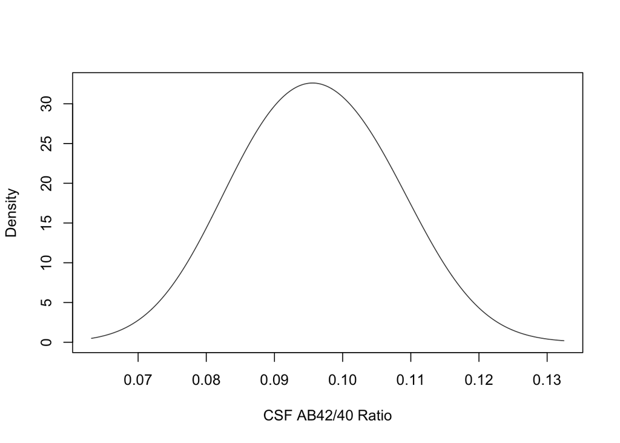

```r
#### CSF ----
LIIA_baseline_noNA <- filter(LIIA_baseline, !is.na(Plasma_ABratio))

fit = Mclust(LIIA_baseline_noNA$Plasma_ABratio, G=2, model="V") ### 2-class
#summary(fit) ## 37 94

plot(fit, what="density", xlab = "CSF AB42/40 Ratio")
```

```r
#plot(fit, what="classification")

fit_classification <- fit$classification ## classification labels ---
LIIA_baseline_noNA$Plasma_classification <- factor(fit_classification, labels=c("Plasma Amyloid negative", "Plasma Amyloid positive"))

### show this: table 1 ----
GMM_Plasma <- data.frame(mean = fit$parameters$mean, variance = fit$parameters$variance$sigmasq, proportion = fit$parameters$pro)
rownames(GMM_Plasma) = c("Plasma Amyloid negative", "Plasma Amyloid positive")

kable(GMM_Plasma,  caption="GMM results for Plasma AB42/40 ratio" )%>%kable_styling()
```

GMM results for Plasma AB42/40 ratio

|  | mean | variance | proportion |
| --- | --- | --- | --- |
| Plasma Amyloid negative | 0.0893010 | 9.09e-05 | 0.4979283 |
| Plasma Amyloid positive | 0.1025865 | 9.58e-05 | 0.5020717 |

```r
#fit$parameters$mean
#fit$parameters$variance
#fit$parameters$pro ### mixture rate ----
```

Based on the classification results from the Plasma data, we identified the optimal cutoff for the Plasma AB42/40 ratio. However, it is important to note that since the Plasma AB42/40 ratio lacks a bimodal distribution, the accuracy of these classification results might be compromised.

```r
#---------------------------------------------------------
#### find the cutpoint based on the clustering
#csf_abeta <- data.frame(class = LIIA_baseline$CSF_classification, ab_ratio = LIIA_dat$`CSF AB42/40 Ratio`)
fit_cutpoint_Plasma <- cutpointr(data = LIIA_baseline_noNA, x = Plasma_ABratio, class=Plasma_classification)
#summary(fit_cutpoint_CSF) ## optimum: 0.0817;

res_Plasma <- data.frame(summary(fit_cutpoint_Plasma)$cutpointr[[1]][,c(2,4:7)])
kable(res_Plasma, caption="Youden's index for Plasma AB42/40 ratio")
```

Youden’s index for Plasma AB42/40 ratio

| optimal_cutpoint | sum_sens_spec | acc | sensitivity | specificity |
| --- | --- | --- | --- | --- |
| 0.0962565 | 2 | 1 | 1 | 1 |

## Comparison

We compared the CSF-based classification results with those derived from the Plasma data. As shown in the table below, the absence of a bimodal distribution in the Plasma data led to the Plasma-based Gaussian mixture model classifying a larger number of subjects as ‘Amyloid negative’ compared to the CSF-based model.

```r
table1( ~ Plasma_classification | CSF_classification, data=LIIA_baseline_noNA)
```

|  | CSF Amyloid negative (N=37) | CSF Amyloid positive (N=93) | Overall (N=130) |
| --- | --- | --- | --- |
| Plasma_classification |  |  |  |
| Plasma Amyloid negative | 35 (94.6%) | 31 (33.3%) | 66 (50.8%) |
| Plasma Amyloid positive | 2 (5.4%) | 62 (66.7%) | 64 (49.2%) |

Finally, given the potential inaccuracies in the Plasma-based sample classification, we use the CSF classification results to find an optimal cutoff for the Plasma AB42/40 ratio.

```r
fit_cutpoint_CSF_Plasma <- cutpointr(data = LIIA_baseline_noNA, x = Plasma_ABratio, class=CSF_classification)
#summary(fit_cutpoint_CSF) ## optimum: 0.0817;

res_CSF_Plasma <- data.frame(summary(fit_cutpoint_CSF_Plasma)$cutpointr[[1]][,c(2,4:7)])
kable(res_CSF_Plasma, caption="Youden's index for Plasma AB42/40 ratio based on CSF classification results")
```

Youden’s index for Plasma AB42/40 ratio based on CSF classification results

| optimal_cutpoint | sum_sens_spec | acc | sensitivity | specificity |
| --- | --- | --- | --- | --- |
| 0.0945272 | 1.650102 | 0.7846154 | 0.7311828 | 0.9189189 |